# HW task 1 and 2

*Maciej Ołdakowski*

# Task 1

We have two populations Blue (privileged) and Red (unprivileged), with the Blue population being 9 times larger than the Red population.

Individuals from both populations are requesting to attend XAI training to improve competency in this important area. Number of places is limited. The administrators of the training have decided to give priority to enrolling individuals who may need this training in the future, although unfortunately it is difficult to predict who will benefit.

The decision rule adopted:

1. In the Red group, half of the people will find the skills useful in future and half will not. Administrators randomly allocate 50% of people to training.
2. In the Blue group, 80% of people will find the training useful in future and 20% will not, although of course it is not known who will find it useful. The administrators have built a predictive model based on user behaviour in predicting for whom it will be useful and whom will not. The model has the following performance:

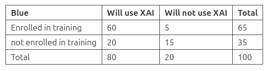

Task: Calculate the Demographic parity, equal opportunity and predictive rate parity coefficients for this decision rule.

Starred task: How can this decision rule be changed to improve its fairness?

def. P(*C*=1|A=a) = P(*C*=1|A=b)

*a* = red group, *b* = blue group

*C*=1 <=> Enrolled in training

Y=1 <=> Will use XAI

**Demographic parity:**

P(*C*=1|A=a) = 50%, P(*C*=1|A=b) = 65%

P(*C*=1|A=a) =/= P(*C*=1|A=b)

Coefficient = P(*C*=1|A=a)/P(*C*=1|=b) = 0.77 Even the "four-fifth rule" is not satisfied.

**Equal opportunities:**

def. P(*C*=1|Y=1,A=a) = P(*C*=1|Y=1,A=b)

P(*C*=1|Y=1,A=a) = 50%, P(*C*=1|Y=1,A=b) = 75%

P(*C*=1|Y=1,A=a) =/= P(*C*=1|Y=1,A=b)

Coefficient = 0.67

**Predictive rate parity coefficients:**

def. P(Y=1|A=a,*C*=1) = P(Y=1|A=b,*C*=1), P(Y=1|A=a,*C*=0) = P(Y=1|A=b,*C*=0)

P(Y=1|A=a,*C*=1) = 50%, P(Y=1|A=b,*C*=1) = 92%

P(Y=1|A=a,*C*=0) = 50%, P(Y=1|A=b,*C*=0) = 57%

P(Y=1|A=a,*C*=1) =/= P(Y=1|A=b,*C*=1), P(Y=1|A=a,*C*=0) =/= P(Y=1|A=b,*C*=0)

Positive_coefficient = 0.54, Negative_coefficient = 0.88

### Starred task:

New model proposition:

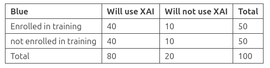

Demographic parity coefficient = 1  
Equal opportunities coefficient = 1  
Predictive rate parity coefficients:

- positive = 0.625
- negative = 0.625

# Task 2

Selected dataset: german_credit_risk  
Protected attribute: gender (presented in data)  
Trained model: XGBoost

Results XGBoost:

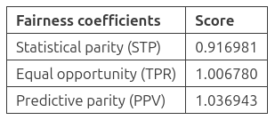

Another model: SVC (each categorical feature transformed into one-hot-encoded)

Results SVC:

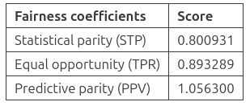

Both Statistical parity and Equal opportunity are similar. The difference in both cases is around 10%. On another hand Predictive parity is almost identical with a difference around 2%. So I would categorize them generally as similar.

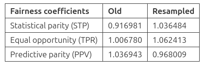

Selected bias mitigation technique: data balancing (resampling)

The scores combined (with extra metrics):

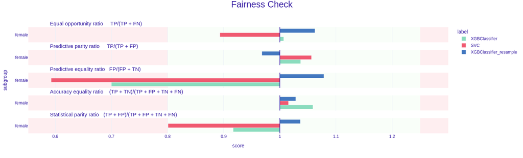

The model has slightly better fairness scores after mitigation (although they were already good, so that's why the impact may be small).

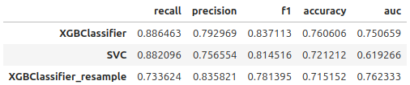

It can be seen that bias mitigation using resampling is lowering performance.